# 第1回 課題の答え合わせ

応用①②③

# 課題

## 応用①：時刻ごとに集計する

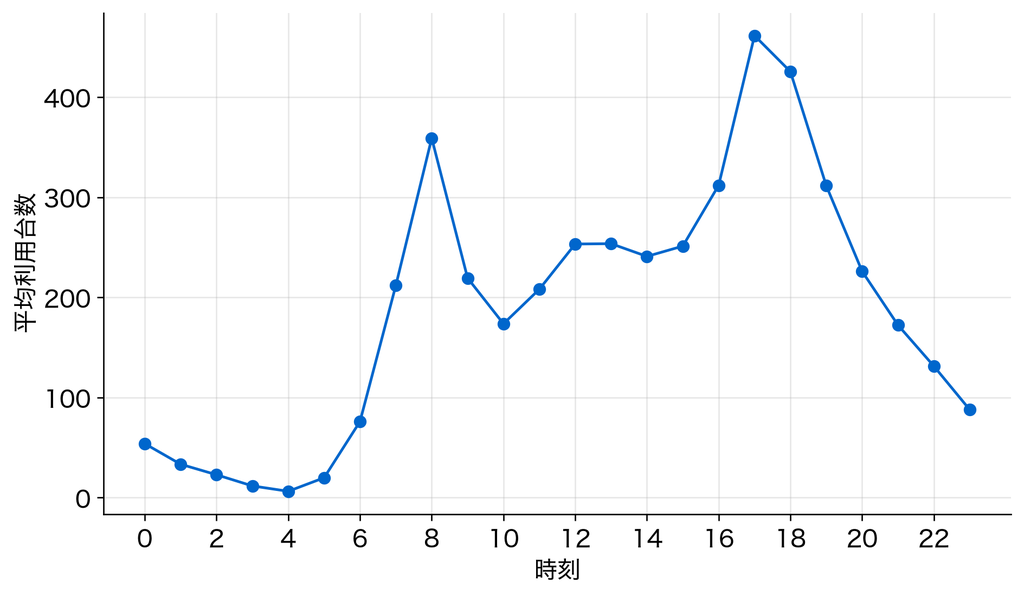

```python
hour = pd.read_csv(f'{DATA_DIR}/bike_hour.csv')
hour = hour.rename(columns=ja_names)        # 1節と同じ前処理
hour = hour.rename(columns={'hr': '時刻'})   # 時間別だけにある列
by_hr = hour.groupby('時刻')['台数'].mean()
by_hr.plot(marker='o', color='#0066cc')
plt.xlabel('時刻'); plt.ylabel('平均利用台数')
plt.xticks(range(0, 24, 2)); plt.grid(alpha=0.3)
plt.show()
```

## 1日の中で、どう変わる？

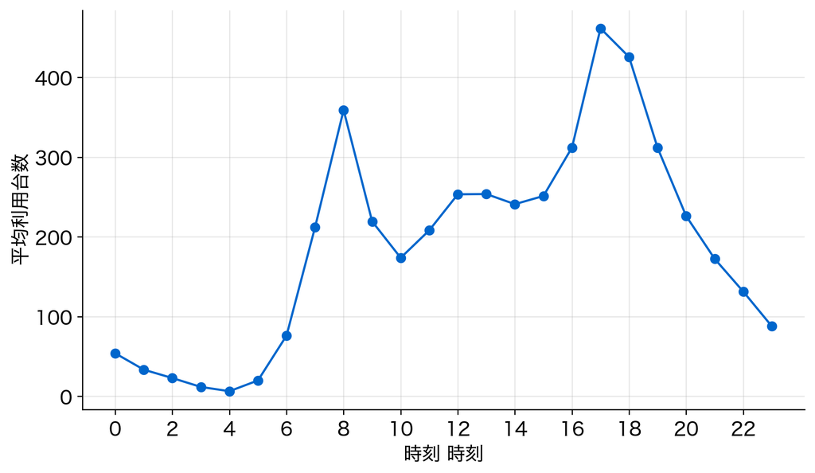

- 横が時刻、縦がその時刻の平均台数

## 山が2つある

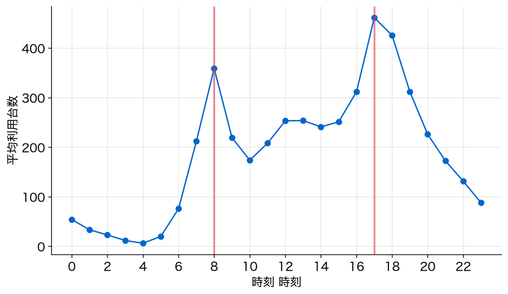

- 朝8時（359台）と、夕方17時（461.5台）。深夜4時は6.4台

## 応用②：最も多い時刻

```python
print('最大の平均台数:', round(by_hr.max(), 1))
print('答え:', int(by_hr.idxmax()))
```

```
最大の平均台数: 461.5
答え: 17
```

- 正答は17。`idxmax()`は、最大値の位置（ここでは時刻）を返す

## 目で見ず、コードで取り出す

```
時刻
16    312.0
17    461.5
18    425.5
```

- 18時（425.5台）とは36台差。グラフを目で見るより、`idxmax()`が確か

## 応用③：模範例

利用は1日の中で一様ではなく、朝8時（平均359台）と夕方17〜18時（約462台・約426台）に2つの山があり、深夜4時は6台まで落ちます。

朝夕の山は通勤・通学の時間帯と重なるので、利用の中心は日常の移動と考えられます。

日次データの合計（1日平均4504台）だけでは見えない「時間帯の偏り」があるので、自転車の配置や整備はこの山に合わせて計画するのがよさそうです。

## 書き方の型

- 1文目：見えた形を、自分の出力の数値で
- 2文目：その形の解釈
- 3文目：相手（運営担当者）にとっての意味

## AIに書かせた文との違い

- 「朝夕に通勤需要がある」の一般論で終わっていないか
- 自分のグラフの数値を根拠にしているか

# まとめ

## まとめと、発展動画へ

- 集計の単位（1日 → 1時間）を変えると、新しい形が見える
- 最も多い時刻は、目で見ず`idxmax`で取り出す
- 文章は、自分の出力の数値を根拠に書く

発展動画：自動EDAレポート（data-profiling）を、ノートの発展セルで動かします。